# Benchmarking

Aleksandrina Goeva

A microbenchmark is a measurement of the performance of a very small piece of code. The best tool for microbenchmarking in R is the `microbenchmark` package. It provides very precise timings, making it possible to compare operations that only take a tiny amount of time.

```r
install.packages('microbenchmark')
```

## Row and Column Means

When we store our data in a `matrix` or a `data.frame`, sometimes we are interested in the summary statistics for the rows or the columns of our data. For example, we might be interested in computing the mean of the rows or the columns. We can get the means using a `for` loop or using the `apply` function. There’s a third option, we could also use the `rowMeans` and the `colMeans` base functions. But which option is the fastest? We can figure this out using the `microbenchmark` package.

```r
library(microbenchmark)
```

First we are going to create a data matrix

```r
m <- 1000
n <- 1000
dat <- matrix(rnorm(m*n),nrow=m,ncol=n)
```

First for the row means

```r
op_rowmean <- microbenchmark(
  for_loop=({res <- rep(NA,dim(dat)[1])
            for(i in 1:dim(dat)[1]){
              res[i] = mean(dat[i,])
            }
  }),
  apply=apply(dat,1,mean),
  rowMeans=rowMeans(dat),
  times=100
  )
```

In `microbenchmark()` first we put in a list the expressions that we want to compare. In this case, we have  
* `for_loop`: computing the row means using a for loop * `apply`: using the `apply` function over the rows to compute the mean * `rowMeans`: using the `rowMeans` function to get the row means.

By default, `microbenchmark()` runs each expression 100 times (controlled by the `times` parameter). It summarises the results with a minimum (`min`), lower quartile (`lq`), `median`, upper quartile (`uq`), and maximum (`max`). Focus on the `median`, and use the upper and lower quartiles (`lq` and `uq`) to get a feel for the variability.

```r
print(op_rowmean)
```

```
## Unit: milliseconds
##      expr       min        lq       mean     median         uq        max
##  for_loop 36.732328 37.178156  38.852777  37.508302  38.221198  83.294240
##     apply 44.863278 85.531501 104.817981 114.849196 116.400931 121.076880
##  rowMeans  5.386279  5.397185   5.414317   5.409159   5.422203   5.529543
##  neval
##    100
##    100
##    100
```

We can also use boxplots to visualize the results

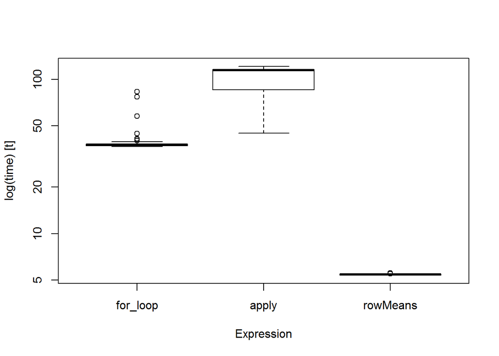

```r
boxplot(op_rowmean)
```

Clearly, the `rowMeans` function is the fastest way to do it. We can do the same comparison for the column means.

```r
op_colmean <- microbenchmark(
  for_loop=({res <- rep(NA,dim(dat)[2])
             for(i in 1:dim(dat)[2]){
               res[i] = mean(dat[,i])
             }
  }),
  apply=apply(dat,2,mean),
  colMeans=colMeans(dat),
  times=100
)
# what's faster?
print(op_colmean)
```

```
## Unit: milliseconds
##      expr       min       lq      mean    median         uq        max
##  for_loop 28.663387 30.33529 35.981007 30.641278  33.548457  85.943972
##     apply 37.697538 56.77147 80.945501 88.102975 102.453912 121.729477
##  colMeans  1.777751  1.79336  1.848296  1.802341   1.813887   3.807815
##  neval
##    100
##    100
##    100
```

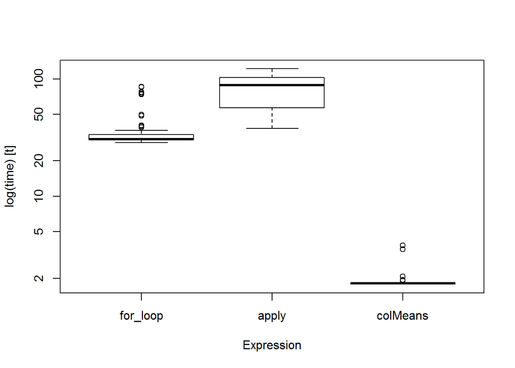

```r
boxplot(op_colmean)
```

Not surprisingly, the `colMeans` function is the fastest way to do it.

## Matrix Statistics

The base R functions only include `rowMeans` and `colMeans`. What if we want to calculate other summary statistics like the median, or the standard deviation?

We could use the `matrixStats` package. This package includes more functions to calculate row and column statistics.

```r
install.packages("matrixStats")
```

The package `matrixStats` includes function to calculate medians, minimums, maximums, standard deviations among other summary statistics.

```r
library(matrixStats)
```

As before, using the `row` and `col` functions is faster than using `for` loops or the `apply` function.

# Median

```r
op_rowmedian <- microbenchmark(
  for_loop=({res <- rep(NA,dim(dat)[1])
             for(i in 1:dim(dat)[1]){
               res[i] = median(dat[i,])
             }
  }),
  apply=apply(dat,1,median),
  rowMedians=rowMedians(dat),
  times=100
)

op_colmedian <- microbenchmark(
  for_loop=({res <- rep(NA,dim(dat)[2])
             for(i in 1:dim(dat)[2]){
               res[i] = median(dat[,i])
             }
  }),
  apply=apply(dat,2,median),
  colMedians=colMedians(dat),
  times=100
)

print(op_rowmedian)
```

```
## Unit: milliseconds
##        expr      min        lq      mean    median        uq       max
##    for_loop 138.2655 140.52971 145.62090 141.55009 143.33895 189.15098
##       apply 135.2805 187.00267 203.82833 217.67217 221.42824 242.68063
##  rowMedians  50.2209  50.60494  51.24857  50.78177  51.17606  63.35282
##  neval
##    100
##    100
##    100
```

```r
print(op_colmedian)
```

```
## Unit: milliseconds
##        expr       min        lq      mean    median        uq      max
##    for_loop 124.18848 124.75597 127.23955 125.63886 126.47877 169.9900
##       apply 134.38370 181.51332 191.00516 196.74480 198.31621 244.9450
##  colMedians  47.31372  47.42042  47.78779  47.46148  47.53974  65.0151
##  neval
##    100
##    100
##    100
```

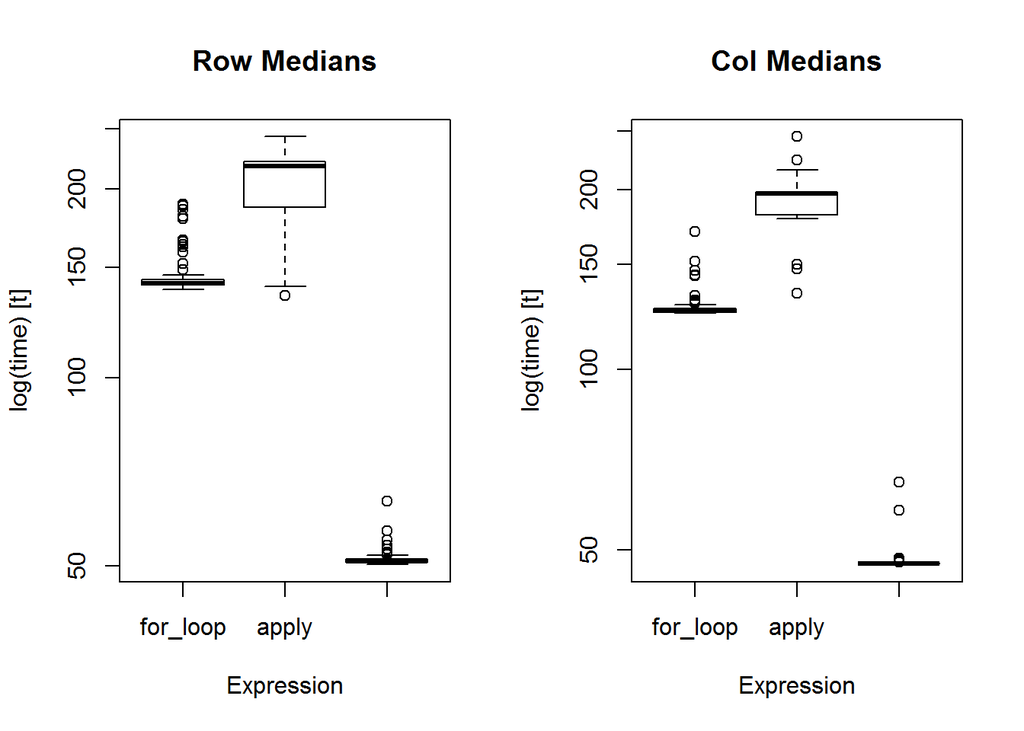

```r
par(mfrow=c(1,2))
boxplot(op_rowmedian,main="Row Medians")
boxplot(op_colmedian,main="Col Medians")
```

```r
par(mfrow=c(1,1))
```

# Standard Deviation

```r
op_rowsd <- microbenchmark(
  for_loop=({res <- rep(NA,dim(dat)[1])
             for(i in 1:dim(dat)[1]){
               res[i] = sd(dat[i,])
             }
  }),
  apply=apply(dat,1,sd),
  rowSds=rowSds(dat),
  times=100
)

op_colsd <- microbenchmark(
  for_loop=({res <- rep(NA,dim(dat)[2])
             for(i in 1:dim(dat)[2]){
               res[i] = sd(dat[,i])
             }
  }),
  apply=apply(dat,2,sd),
  colSds=colSds(dat),
  times=100
)

print(op_rowsd)
```

```
## Unit: milliseconds
##      expr      min        lq       mean     median         uq       max
##  for_loop 53.47919 54.802983  59.806860  55.470121  56.642529 119.47404
##     apply 57.74758 95.795153 111.759319 106.925657 139.606835 187.34971
##    rowSds  9.10386  9.254179   9.771245   9.337357   9.535147  19.72546
##  neval
##    100
##    100
##    100
```

```r
print(op_colsd)
```

```
## Unit: milliseconds
##      expr       min        lq      mean     median         uq       max
##  for_loop 45.238757 46.603395 50.290838  46.884789  47.317360  95.98781
##     apply 54.873760 74.307130 99.885518 105.229802 119.497989 126.14883
##    colSds  6.281356  6.324762  6.474334   6.342938   6.392973  13.11951
##  neval
##    100
##    100
##    100
```

[figure not shown]

```r
par(mfrow=c(1,2))
boxplot(op_rowsd,main="Row Medians")
boxplot(op_colsd,main="Col Medians")
```

```r
par(mfrow=c(1,1))
```